# Project 4

Igor Balagula

March 27, 2017

## Objective

practice evaluating the performance of recommender systems.

## Data

Load data

```r
setwd("E:\\Igor\\CUNY\\DATA 643 - Recommender Systems\\Projects\\Project_04\\Data")
ratings<-read.csv("ratings.csv")
movies<-read.csv("movies.csv",stringsAsFactors=FALSE)
```

Review loaded data

```r
head(ratings)
```

```
##   userId movieId rating  timestamp
## 1      1      31    2.5 1260759144
## 2      1    1029    3.0 1260759179
## 3      1    1061    3.0 1260759182
## 4      1    1129    2.0 1260759185
## 5      1    1172    4.0 1260759205
## 6      1    1263    2.0 1260759151
```

```r
head(movies)
```

```
##   movieId                              title
## 1       1                   Toy Story (1995)
## 2       2                     Jumanji (1995)
## 3       3            Grumpier Old Men (1995)
## 4       4           Waiting to Exhale (1995)
## 5       5 Father of the Bride Part II (1995)
## 6       6                        Heat (1995)
##                                        genres
## 1 Adventure|Animation|Children|Comedy|Fantasy
## 2                  Adventure|Children|Fantasy
## 3                              Comedy|Romance
## 4                        Comedy|Drama|Romance
## 5                                      Comedy
## 6                       Action|Crime|Thriller
```

Remove timestap from ratings dataframe

```r
ratings <- ratings[,c(1,2,3)]
```

Create ratings matrix. Rows = userId, Columns = movieId

```r
ratingmat <- dcast(ratings, userId~movieId, value.var = "rating", na.rm=FALSE)
```

Remove userIds in the first column

```r
ratingmat <- as.matrix(ratingmat[,-1])
```

Convert rating matrix into a recommenderlab sparse matrix

```r
ratingmat <- as(ratingmat, "realRatingMatrix")
ratingmat
```

```
## 672 x 9069 rating matrix of class 'realRatingMatrix' with 100024 ratings.
```

Let’s see how ratings are distributed

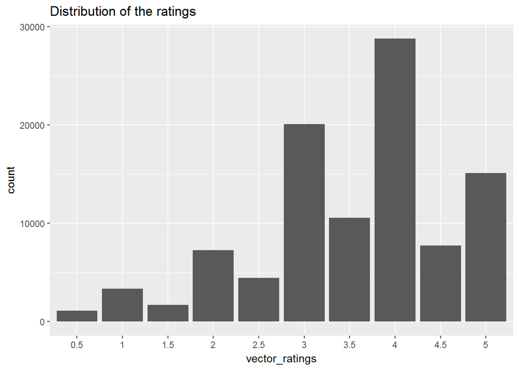

```r
vector_ratings <- as.vector(ratingmat@data)
vector_ratings <- vector_ratings[vector_ratings != 0]
vector_ratings <- factor(vector_ratings)
qplot(vector_ratings) + ggtitle("Distribution of the ratings")
```

The most common rating is 4.

Now let’s see how the average ratings for each individual movie are distributed

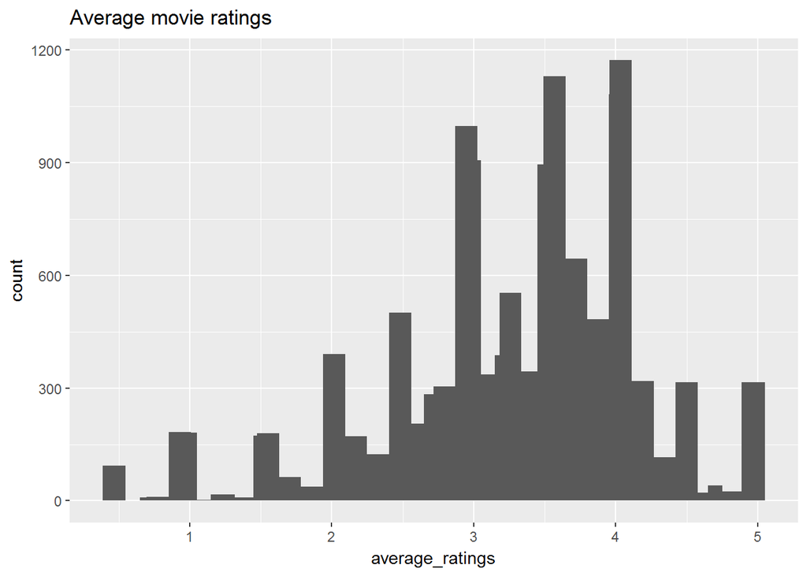

```r
average_ratings <- colMeans(ratingmat)
qplot(average_ratings) + stat_bin(binwidth = 0.1) +
ggtitle("Average movie ratings")
```

To remove some extreme cases (with very small number of ratings) we will reduce the matrix - select only those movies that were rated 50 or more times and only users who rated 50 or more movies

```r
ratingmat <- ratingmat[rowCounts(ratingmat)>= 50,colCounts(ratingmat)>=50 ]
ratingmat
```

```
## 427 x 453 rating matrix of class 'realRatingMatrix' with 38538 ratings.
```

Separate data into a training and test data sets (as described in the textbook p.78)

```r
set.seed(1)
percentage_training <-0.8
items_to_keep <- 5
rating_threshold <- 3
n_eval <- 1
eval_sets <- evaluationScheme(data=ratingmat, method="split", train=percentage_training, given=items_to_keep,
goodRating=rating_threshold,k=n_eval)
d<-eval_sets
getData(eval_sets, "train")
```

```
## 341 x 453 rating matrix of class 'realRatingMatrix' with 30234 ratings.
```

Now we will evaluate prediction models with different parameters. First create a function to generate predictions and get RMSE for each method.

```r
predict_by_method <- function(p_data,p_method,p_normalize,p_dist_method,p_n)
{
recommender_model <- Recommender(getData(p_data, "train"), p_method, param=list(p_normalize ,p_dist_method,p_n))
recom <- predict(recommender_model,getData(p_data, "known"), type="ratings")
predict_acc_ubcf_cosine_z <- calcPredictionAccuracy(recom, getData(p_data, "unknown"))[1]
return (predict_acc_ubcf_cosine_z)
}
```

1. User-based collaborative filtering; distance method = cosine; normalize= “Z-Score”

```r
predict_acc_ubcf_cosine_z <- predict_by_method(d,"UBCF","Z-Score","Cosine",30)
print (predict_acc_ubcf_cosine_z)
```

```
##      RMSE
## 0.9588535
```

2. User-based collaborative filtering; distance method = jaccard; normalize= “Z-Score”

```r
predict_acc_ubcf_jaccard_z <- predict_by_method(d,"UBCF","Z-Score","jaccard",30)
print (predict_acc_ubcf_jaccard_z)
```

```
##      RMSE
## 0.9588535
```

3. User-based collaborative filtering; distance method = pearson; normalize= “Z-Score”

```r
predict_acc_ubcf_pearson_z <- predict_by_method(d,"UBCF","Z-Score","pearson",30)
print (predict_acc_ubcf_pearson_z)
```

```
##      RMSE
## 0.9588535
```

4. Item-based collaborative filtering; distance method = cosine; normalize= “Z-Score”

```r
predict_acc_ibcf_cosine_z <- predict_by_method(d,"IBCF","Z-Score","cosine",30)
print (predict_acc_ibcf_cosine_z)
```

```
##     RMSE
## 1.183001
```

5. Item-based collaborative filtering; distance method = jaccard; normalize= “Z-Score”

```r
predict_acc_ibcf_jaccard_z <- predict_by_method(d,"IBCF","Z-Score","jaccard",30)
print (predict_acc_ibcf_jaccard_z)
```

```
##     RMSE
## 1.183001
```

6. Item-based collaborative filtering; distance method = pearson; normalize= “Z-Score”

```r
predict_acc_ibcf_pearson_z <- predict_by_method(d,"IBCF","Z-Score","pearson",30)
print (predict_acc_ibcf_pearson_z)
```

```
##     RMSE
## 1.183001
```

7. User-based collaborative filtering; distance method = cosine; normalize= “center”

```r
predict_acc_ubcf_cosine_c <- predict_by_method(d,"UBCF","center","Cosine",30)
print (predict_acc_ubcf_cosine_c)
```

```
##      RMSE
## 0.9588535
```

8. User-based collaborative filtering; distance method = jaccard; normalize= “center”

```r
predict_acc_ubcf_jaccard_c <- predict_by_method(d,"UBCF","center","jaccard",30)
print (predict_acc_ubcf_jaccard_c)
```

```
##      RMSE
## 0.9588535
```

9. User-based collaborative filtering; distance method = pearson; normalize= “center”

```r
predict_acc_ubcf_pearson_c <- predict_by_method(d,"UBCF","center","pearson",30)
print (predict_acc_ubcf_pearson_c)
```

```
##      RMSE
## 0.9588535
```

10. Item-based collaborative filtering; distance method = cosine; normalize= “center”

```r
predict_acc_ibcf_cosine_c <- predict_by_method(d,"IBCF","center","cosine",30)
print (predict_acc_ibcf_cosine_c)
```

```
##     RMSE
## 1.183001
```

11. Item-based collaborative filtering; distance method = jaccard; normalize= “center”

```r
predict_acc_ibcf_jaccard_c <- predict_by_method(d,"IBCF","center","jaccard",30)
print (predict_acc_ibcf_jaccard_c)
```

```
##     RMSE
## 1.183001
```

12. Item-based collaborative filtering; distance method = pearson; normalize= “center”

```r
predict_acc_ibcf_pearson_c <- predict_by_method(d,"IBCF","center","pearson",30)
print (predict_acc_ibcf_pearson_c)
```

```
##     RMSE
## 1.183001
```

Generate ROC and precision/recall curves for UBCF algorithms

```r
eval_ubcf_list <- list(
  "Center_Cosine" = list(name="UBCF", param=list(normalize = "center",
                                         method="Cosine",
                                         nn=30)),
  "Z-score_Cosine" = list(name="UBCF", param=list(normalize = "Z-score",
                                         method="Cosine",
                                         nn=30)),
  "Center_jaccard" = list(name="UBCF", param=list(normalize = "center",
                                         method="jaccard",
                                         nn=30)),
  "Z-score_jaccard" = list(name="UBCF", param=list(normalize = "Z-score",
                                         method="jaccard",
                                         nn=30)),
  "Center_pearson" = list(name="UBCF", param=list(normalize = "center",
                                         method="pearson",
                                         nn=30)),
  "Z-score_pearson" = list(name="UBCF", param=list(normalize = "Z-score",
                                         method="pearson",
                                         nn=30))
)
number_of_recomm <- c(1,5, 10, 15, 20, 25)
eval_ubcf <- evaluate(d, eval_ubcf_list , n = number_of_recomm , progress = FALSE)
```

```
## UBCF run fold/sample [model time/prediction time]
##   1  [0sec/0.25sec]
## UBCF run fold/sample [model time/prediction time]
##   1  [0.03sec/0.26sec]
## UBCF run fold/sample [model time/prediction time]
##   1  [0.01sec/0.29sec]
## UBCF run fold/sample [model time/prediction time]
##   1  [0.03sec/0.2sec]
## UBCF run fold/sample [model time/prediction time]
##   1  [0.02sec/0.22sec]
## UBCF run fold/sample [model time/prediction time]
##   1  [0.01sec/0.22sec]
```

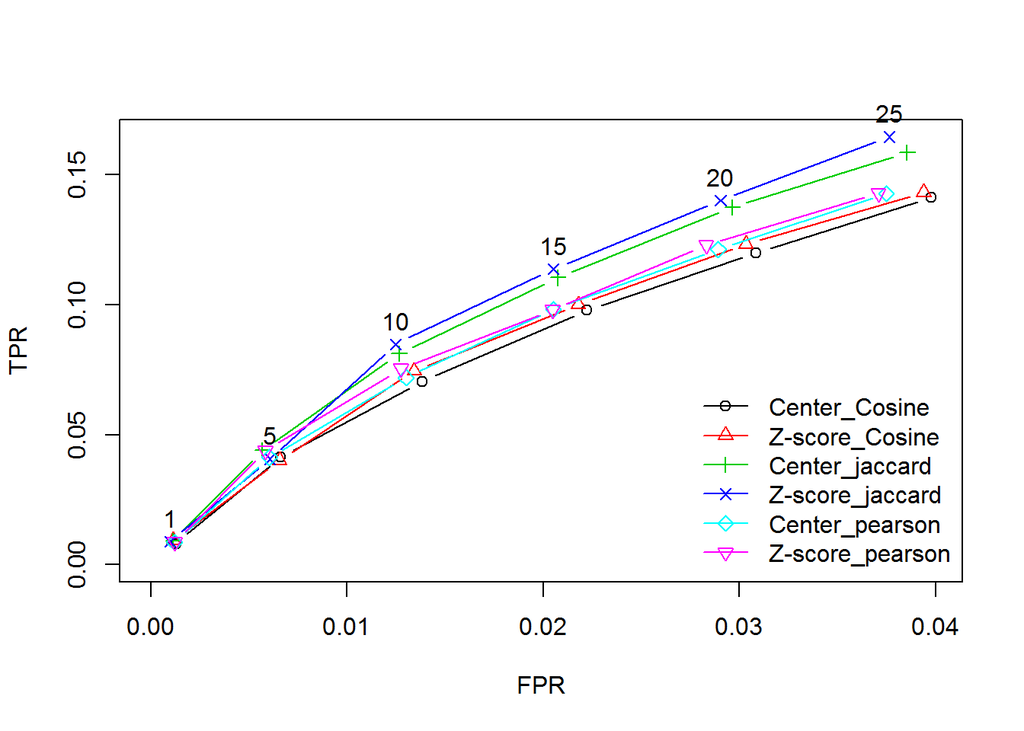

```r
plot(x = eval_ubcf, y = "ROC", annotate = 4)
```

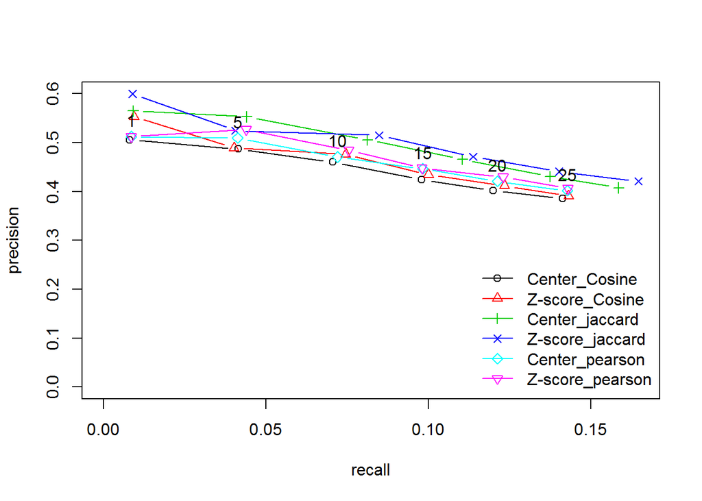

```r
plot(x = eval_ubcf, y = "prec/rec", annotate = 5)
```

Generate ROC and precision/recall curves for IBCF algorithms

```r
eval_ibcf_list <- list(
  "Center_Cosine" = list(name="IBCF", param=list(normalize = "center",
                                         method="Cosine",
                                         k=10)),
  "Z-score_Cosine" = list(name="IBCF", param=list(normalize = "Z-score",
                                         method="Cosine",
                                         k=10)),
  "Center_jaccard" = list(name="IBCF", param=list(normalize = "center",
                                         method="jaccard",
                                         k=10)),
  "Z-score_jaccard" = list(name="IBCF", param=list(normalize = "Z-score",
                                         method="jaccard",
                                         k=10)),
  "Center_pearson" = list(name="IBCF", param=list(normalize = "center",
                                         method="pearson",
                                         k=10)),
  "Z-score_pearson" = list(name="IBCF", param=list(normalize = "Z-score",
                                         method="pearson",
                                         k=10))
)

eval_ibcf <- evaluate(d, eval_ibcf_list , n = number_of_recomm , progress = FALSE)
```

```
## IBCF run fold/sample [model time/prediction time]
##   1  [0.65sec/0.03sec]
## IBCF run fold/sample [model time/prediction time]
##   1  [0.69sec/0.03sec]
## IBCF run fold/sample [model time/prediction time]
##   1  [0.5sec/0.03sec]
## IBCF run fold/sample [model time/prediction time]
##   1  [0.47sec/0.03sec]
## IBCF run fold/sample [model time/prediction time]
##   1  [0.66sec/0.03sec]
## IBCF run fold/sample [model time/prediction time]
##   1  [0.67sec/0.03sec]
```

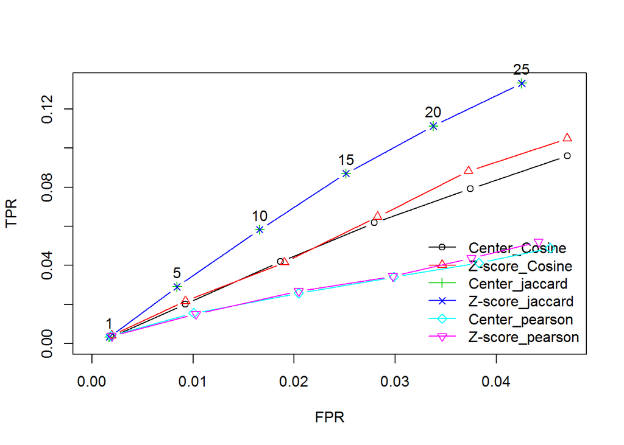

```r
plot(x = eval_ibcf, y = "ROC", annotate = 4)
```

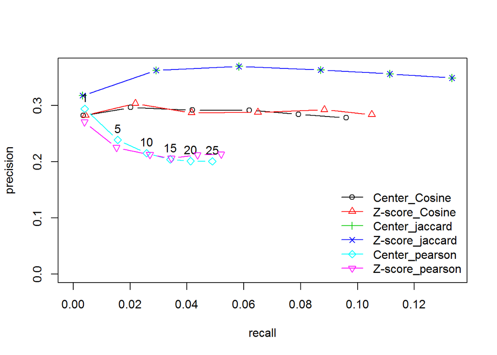

```r
plot(x = eval_ibcf, y = "prec/rec", annotate = 5)
```

## Conclusion

By analyzing ROC and precision/recall curves we can draw the following conclusions:

- User-based collaborative filtering provides better predictions as compared to the item-based collaborative filtering
- Within UBCF the best predictions are generated by a combination of “jaccard” distance method with the Z-score normalization method.
- RMSE value for “jaccard” Z-score UBCF is 0.958853 is one of the equally-low values among UBCF algorithms and is lower than any RMSE values generated by any IBCF algorithm.

In conclusion the UBCF algorithm utilizing “jaccard” distance method and Z-score normalization provides the best prediction accuracy.